# Metric Scaling

Eveline Surbakti - 19200629

3/31/2020

### 2 (a) Apply classical metric scaling to the data, explaining any decisions you make in the process.

```r
# Import the data.
hyptis<-read.csv("Hyptis.csv")
# summary(hyptis)
# Get all numerical data
# decided to not scale at the moment because they are the concentration and measured using the terpene measures
hyptis_data<-(hyptis[,-8])
```

Choose a suitable number of dimensions required to represent the resulting configuration. Explain, using a graphic to support your argument, your reasoning behind your choice of the required number of dimensions.

**Answer**: We can see from the data, it only has 30 observations, this is quite small and we need to represent the resulting configuration.

```r
library(mclust)
```

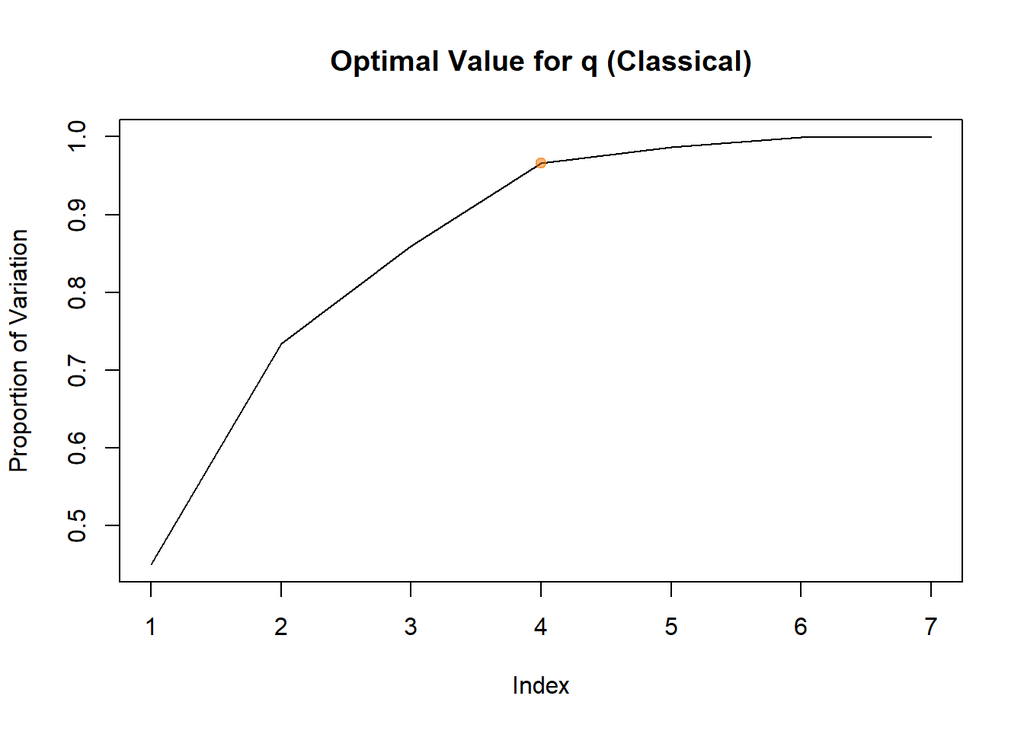

```r
# generate the cmdscale based on the different k
loc1 = cmdscale(dist(hyptis_data), k=1, eig=TRUE)
loc2 = cmdscale(dist(hyptis_data), k=2, eig=TRUE)
loc3 = cmdscale(dist(hyptis_data), k=3, eig=TRUE)
loc4 = cmdscale(dist(hyptis_data), k=4, eig=TRUE)
loc5 = cmdscale(dist(hyptis_data), k=5, eig=TRUE)
loc6 = cmdscale(dist(hyptis_data), k=6, eig=TRUE)
loc7 = cmdscale(dist(hyptis_data), k=7, eig=TRUE)

# proportion of variation
x<- c(sum(abs(loc1$eig[1:1]))/sum(abs(loc1$eig)),
sum(abs(loc2$eig[1:2]))/sum(abs(loc2$eig)),
sum(abs(loc3$eig[1:3]))/sum(abs(loc3$eig)),
sum(abs(loc4$eig[1:4]))/sum(abs(loc4$eig)),
sum(abs(loc5$eig[1:5]))/sum(abs(loc5$eig)),
sum(abs(loc6$eig[1:6]))/sum(abs(loc6$eig)),
sum(abs(loc7$eig[1:7]))/sum(abs(loc7$eig)))

plot(x ,type = "l", ylab = "Proportion of Variation", main ="Optimal Value for q (Classical)")
points(4,sum(abs(loc4$eig[1:4]))/sum(abs(loc4$eig)), pch = 19, col = adjustcolor("darkorange2", 0.5))
```

```r
# 4 dimension is the best answer! to avoid the overfitting and get enough representation of the data
```

I provided k up to 7 dimensions to see the proportionality of variation. It is known that the best k is the one that give the greater representation of the data. Let us examine, in every visualization, two dimension will always give a great representation as the start and in this case it give more than 70% proportion of variation which is still acceptable. It gets higher as we increase the dimensions.

Plot the two dimensional configuration resulting from the application of classical metric scaling. Label each point in your plot using the geographical location of each plant.

**Answer**:

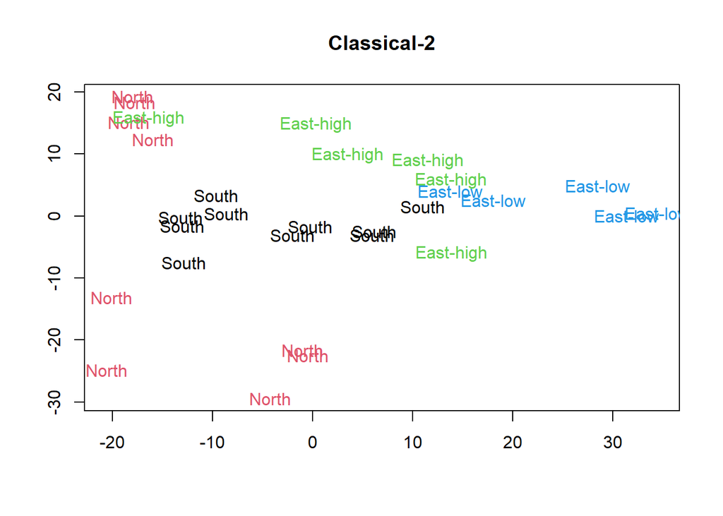

```r
# Code the geographical location of each plant.
S = which(hyptis[,8] == "South")
N = which(hyptis[,8] == "North")
EH = which(hyptis[,8] == "East-high")
EL = which(hyptis[,8] == "East-low")

x2=loc2$points[,1]
y2=loc2$points[,2]
cols=c(rep(1,10),rep(2,9),rep(3,6),rep(4,5))
plot(x2, y2, type="n", xlab="", ylab="", main="Classical-2")
text(x2, y2, hyptis[c(S,N,EH,EL),8], cex=1, col=cols)
```

The geographical location with different colors in the graph show us the clustering for the observations. It is well present despite of a few observations may located in other cluster area.

### 2 (b) Apply Sammon’s metric least squares scaling and Kruskal’s non-metric scaling to the data.

**Answer**:

```r
library(MASS)
# SAMMON
# generate the sammon based on the different k
loc11 = sammon(dist(hyptis_data), k=1)
```

```
## Initial stress        : 0.26140
## stress after  10 iters: 0.16214, magic = 0.500
## stress after  20 iters: 0.16212, magic = 0.500
```

```r
loc21 = sammon(dist(hyptis_data), k=2)
```

```
## Initial stress        : 0.06787
## stress after  10 iters: 0.02647, magic = 0.500
## stress after  20 iters: 0.02612, magic = 0.500
## stress after  30 iters: 0.02546, magic = 0.500
## stress after  40 iters: 0.02464, magic = 0.500
## stress after  50 iters: 0.02446, magic = 0.500
## stress after  60 iters: 0.02445, magic = 0.500
```

```r
loc31 = sammon(dist(hyptis_data), k=3)
```

```
## Initial stress        : 0.02787
## stress after  10 iters: 0.01018, magic = 0.500
## stress after  20 iters: 0.00891, magic = 0.500
## stress after  30 iters: 0.00752, magic = 0.500
## stress after  40 iters: 0.00726, magic = 0.500
## stress after  50 iters: 0.00641, magic = 0.500
## stress after  60 iters: 0.00621, magic = 0.500
## stress after  70 iters: 0.00616, magic = 0.500
```

```r
loc41 = sammon(dist(hyptis_data), k=4)
```

```
## Initial stress        : 0.00216
## stress after  10 iters: 0.00081, magic = 0.461
## stress after  20 iters: 0.00068, magic = 0.500
## stress after  30 iters: 0.00068, magic = 0.500
```

```r
loc51 = sammon(dist(hyptis_data), k=5)
```

```
## Initial stress        : 0.00040
## stress after  10 iters: 0.00010, magic = 0.500
## stress after  20 iters: 0.00009, magic = 0.500
```

```r
loc61 = sammon(dist(hyptis_data), k=6)
```

```
## Initial stress        : 0.00000
## stress after  10 iters: 0.00000, magic = 0.150
```

```r
loc71 = sammon(dist(hyptis_data), k=7)
```

```
## Initial stress        : 0.00000
## stress after   9 iters: 0.00000
```

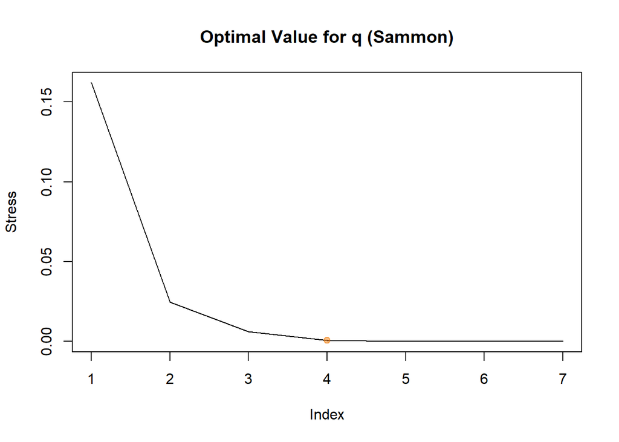

```r
# the stress
x1<- c(loc11$stress,loc21$stress,loc31$stress,loc41$stress,loc51$stress
       ,loc61$stress,loc71$stress)

# minimizing the stress
plot(x1 ,type = "l", ylab = "Stress", main ="Optimal Value for q (Sammon)")
points(4,loc41$stress, pch = 19, col = adjustcolor("darkorange2", 0.5))
```

```r
# 4 dimension is the best answer! to avoid the overfitting and get enough representation of the data while minimizing the stress
```

```r
# Kruskal
# generate the isoMDS based on the different k
loc12 = isoMDS(dist(hyptis_data), k=1)
loc22 = isoMDS(dist(hyptis_data), k=2)
loc32 = isoMDS(dist(hyptis_data), k=3)
loc42 = isoMDS(dist(hyptis_data), k=4)
loc52 = isoMDS(dist(hyptis_data), k=5)
loc62 = isoMDS(dist(hyptis_data), k=6)
loc72 = isoMDS(dist(hyptis_data), k=7)
```

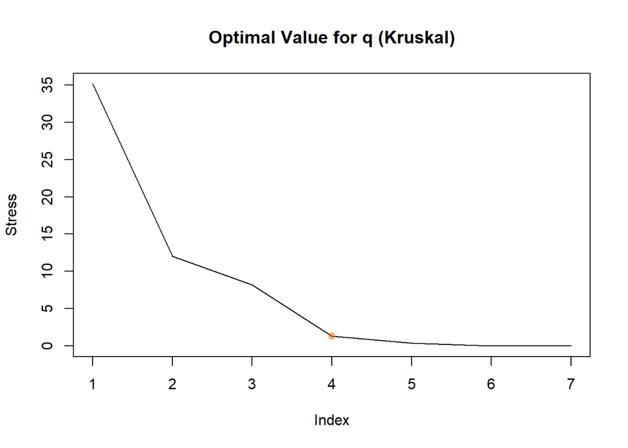

```r
# the stress
x2<- c(loc12$stress,loc22$stress,loc32$stress,loc42$stress,loc52$stress
       ,loc62$stress,loc72$stress)

# minimizing the stress
plot(x2 ,type = "l", ylab = "Stress", main ="Optimal Value for q (Kruskal)")
points(4,loc42$stress, pch = 19, col = adjustcolor("darkorange2", 0.5))
```

```r
# 4 dimension is the best answer! to avoid the overfitting and get enough representation of the data while minimizing the stress
```

Overlay the resulting two dimensional configurations on your plot of the classical scaling configuration. Label each point using the observation number of the associated plant.

**Answer**: The graphs show that the scale for both is different, we can see that both graphs look pretty similar despite of few observations have the different location. For example, we can see the observation 15 and 16 in both graphs, while the metric least square scaling shows that both observations are located closer to observation 14 but in the Kruskal’s non metric scaling, both observations now closer to observation 19.

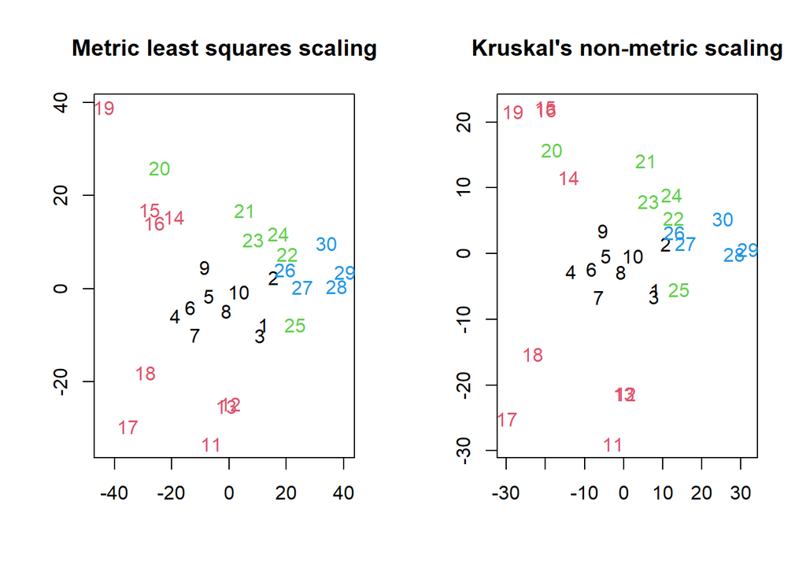

```r
x21 = loc11$points[,1]
y21 = loc21$points[,2]
x22 = loc12$points[,1]
y22 = loc22$points[,2]

par(mfrow=c(1,2))
plot(x21, y21, type="n", xlab="", ylab="",main="Metric least squares scaling")
text(x21, y21, #hyptis[c(S,N,EH,EL),8],
     cex=1, col=cols)
plot(x22, y22, type="n", xlab="", ylab="", main="Kruskal's non-metric scaling")
text(x22, y22, #hyptis[c(S,N,EH,EL),8],
     cex=1, col=cols)
```

### 2(c) Use Procrustes analysis to match the three resulting configurations of the plants.

**Answer**: I use four dimensional in this analysis.

```r
 #install.packages("vegan")
 library(vegan)
```

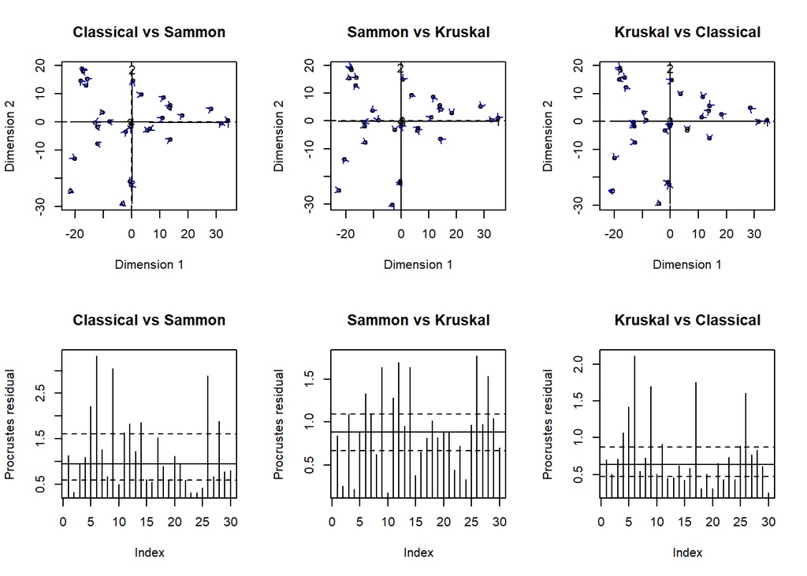

```r
 proc12 = procrustes(loc4$points, loc41$points)
 proc23 = procrustes(loc41$points, loc42$points)
 proc31 = procrustes(loc42$points, loc4$points)

 par(mfrow=c(2,3))
 plot(proc12, main = "Classical vs Sammon")
 plot(proc23, main = "Sammon vs Kruskal")
 plot(proc31, main= "Kruskal vs Classical")
 plot(proc12, kind=2, main = "Classical vs Sammon")
 plot(proc23, kind=2, main = "Sammon vs Kruskal")
 plot(proc31, kind=2, main= "Kruskal vs Classical")
```

Function Procrustes rotates a configuration to maximum similarity with another configuration. Let us examine the comparison between the Classical, Sammon and Kruskal configuration. The first row graphs are ordination diagrams while the second row is the residuals between both configurations.

In the first row, all of the graphs show that all of the observations are located almost in a similar location and so do the arrows head directions. For the second row, the residuals between the configuration are distinct from one another especially the scale.

Which configurations match best? Suggest a reason for your conclusion. **Answer**: So far, among the comparisons, Kruskal vs Classical is very similar with most of the residuals below 0.9, the configurations match best. It supposed to happen because isoMDS function originally will set its y (as a part of the function) as an initial configuration. And since none is supplied, cmdscale is used (as y) to provide the classical solution, unless there are missing or infinite dissimilarities.

### 2 (d) Perform model-based clustering on these data.

Model-based clustering based on parameterized finite Gaussian mixture models. Models are estimated by EM algorithm initialized by hierarchical model-based agglomerative clustering. The optimal model is then selected according to BIC.

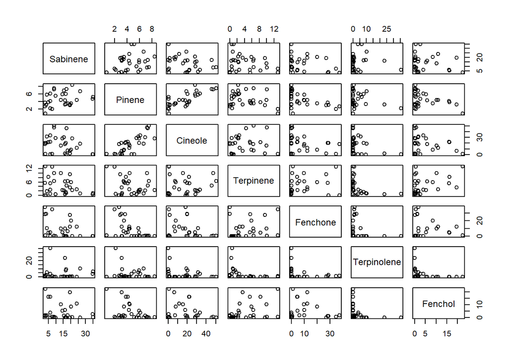

```r
# Clustering the data, checking the pairs plot first
library(mclust)
# we can visualize the data with this plot
pairs(hyptis_data)
```

```r
res = Mclust(hyptis_data, G=1:7, verbose = FALSE)
summary(res)
```

```
## ----------------------------------------------------
## Gaussian finite mixture model fitted by EM algorithm
## ----------------------------------------------------
##
## Mclust VEV (ellipsoidal, equal shape) model with 6 components:
##
##  log-likelihood  n  df       BIC       ICL
##        -273.297 30 185 -1175.816 -1175.816
##
## Clustering table:
##  1  2  3  4  5  6
## 10  8  4  3  2  3
```

```r
#will give us the BIC and top 3 models
res$BIC
```

```
## Bayesian Information Criterion (BIC):
##         EII       VII       EEI       VEI       EVI       VVI       EEE
## 1 -1534.671 -1534.671 -1430.731 -1430.731 -1430.731 -1430.731 -1363.418
## 2 -1516.394 -1492.713 -1416.033 -1395.465 -1398.577 -1387.067 -1378.315
## 3 -1490.860 -1463.129 -1404.612 -1385.553 -1392.777 -1365.842 -1381.151
## 4 -1479.260 -1460.120 -1377.685 -1374.947        NA        NA -1364.810
## 5 -1475.484 -1435.108 -1391.356 -1355.610        NA        NA -1350.639
## 6 -1458.831 -1400.271 -1387.737 -1349.284        NA        NA -1339.974
## 7 -1452.880 -1429.906 -1365.618 -1338.798        NA        NA -1329.136
##         EVE       VEE       VVE       EEV       VEV       EVV       VVV
## 1 -1363.418 -1363.418 -1363.418 -1363.418 -1363.418 -1363.418 -1363.418
## 2 -1348.799 -1373.693 -1349.190 -1406.801 -1391.472 -1400.549 -1377.730
## 3        NA        NA        NA -1422.666 -1400.862        NA        NA
## 4        NA        NA        NA -1286.380 -1400.790        NA        NA
## 5        NA        NA        NA -1273.187 -1320.322        NA        NA
## 6        NA        NA        NA -1302.723 -1175.816        NA        NA
## 7        NA        NA        NA        NA        NA        NA        NA
##
## Top 3 models based on the BIC criterion:
##     VEV,6     EEV,5     EEV,4
## -1175.816 -1273.187 -1286.380
```

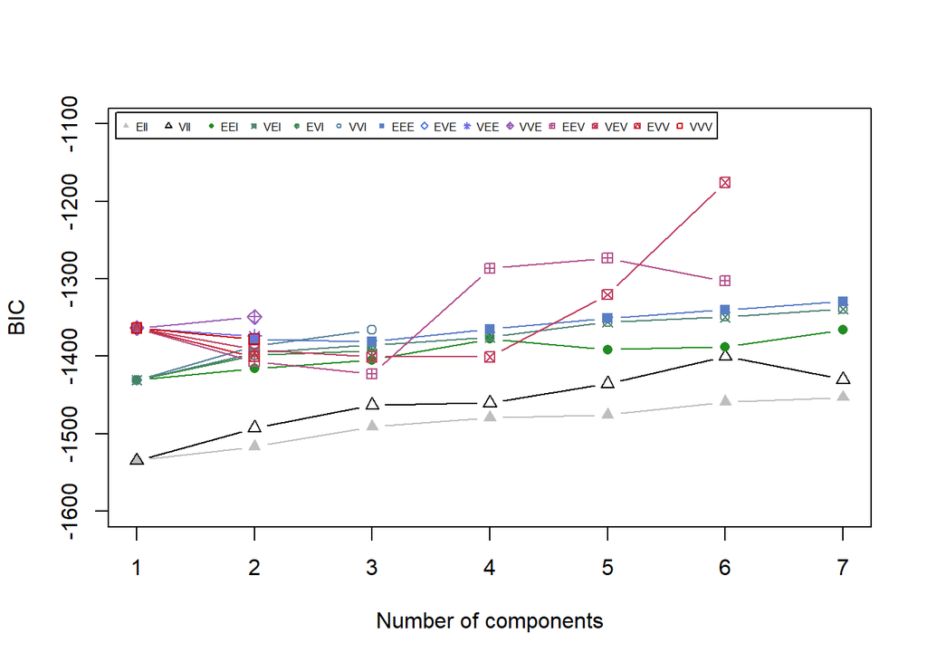

```r
plot(res, what="BIC", legendArgs = list(x="topleft", cex=0.5,horiz=T),ylim=c(-1600, -1100))
```

The optimal model is often chosen using the Bayesian information criterion (BIC): This criterion is calculated for each different type of model fitted and the model which has the largest value of this criterion is deemed to be the optimal model.

How many clusters are chosen as optimal? Explain how you arrived at your answer.

Here is the resulting clusters.

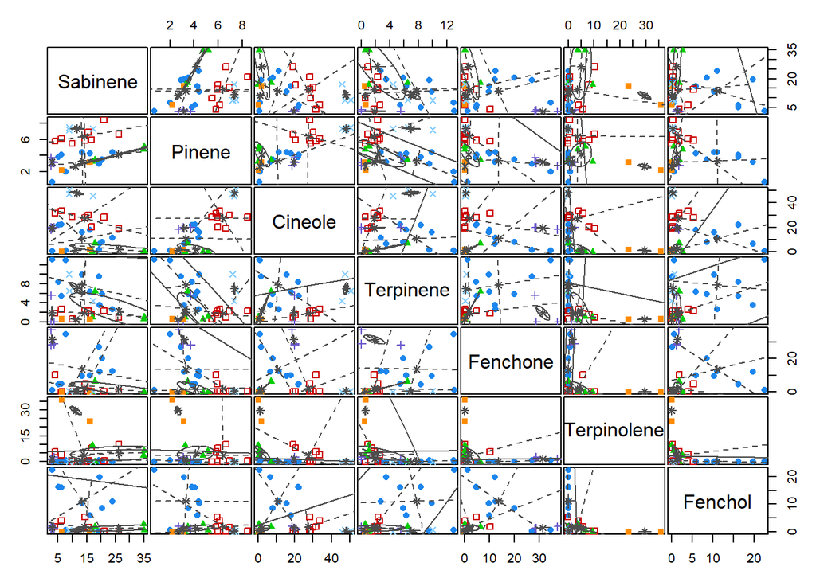

```r
plot(res, what="classification")
```

Here is the clustering uncertainty.

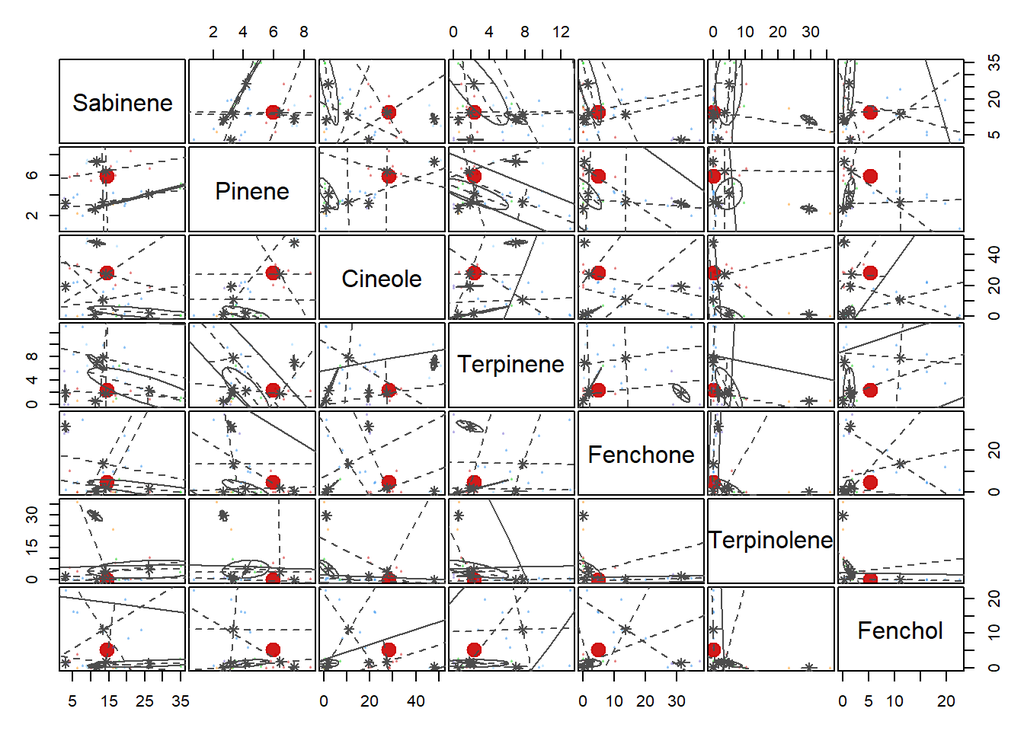

```r
plot(res, what="uncertainty")
```

And the clusters size:

```r
table(res$classification) # see cluster size
```

```
##
##  1  2  3  4  5  6
## 10  8  4  3  2  3
```